# Mortalidad

Evangelina

2023-07-18

## Datos

Data summary

| Name | Piped data |
| --- | --- |
| Number of rows | 90 |
| Number of columns | 12 |
| _______________________ |  |
| Column type frequency: |  |
| numeric | 12 |
| ________________________ |  |
| Group variables | None |

**Variable type: numeric**

| skim_variable | n_missing | complete_rate | mean | sd | p0 | p25 | p50 | p75 | p100 | hist |
| --- | --- | --- | --- | --- | --- | --- | --- | --- | --- | --- |
| vacination | 0 | 1 | 2.53 | 0.60 | 1 | 2 | 3 | 3 | 3.0 | ▁▁▅▁▇ |
| prepartum | 0 | 1 | 2.39 | 0.63 | 1 | 2 | 2 | 3 | 3.0 | ▁▁▇▁▇ |
| experience | 0 | 1 | 3.13 | 1.04 | 1 | 2 | 4 | 4 | 4.0 | ▁▅▁▂▇ |
| capacitations | 0 | 1 | 1.57 | 0.75 | 1 | 1 | 1 | 2 | 3.0 | ▇▁▃▁▂ |
| rearing_system | 0 | 1 | 1.90 | 0.46 | 1 | 2 | 2 | 2 | 2.5 | ▂▁▁▇▂ |
| realiza_calostrado | 0 | 1 | 1.83 | 0.66 | 1 | 1 | 2 | 2 | 3.0 | ▅▁▇▁▂ |
| calostrum_feeding_num | 0 | 1 | 1.60 | 0.65 | 1 | 1 | 2 | 2 | 3.0 | ▇▁▇▁▂ |
| clostrum_feeding_vol | 0 | 1 | 3.41 | 1.16 | 1 | 3 | 4 | 4 | 5.0 | ▁▅▆▇▅ |
| liquid_feeding_volume | 0 | 1 | 2.37 | 0.51 | 1 | 2 | 2 | 3 | 3.0 | ▁▁▇▁▅ |
| hygiene | 0 | 1 | 2.27 | 0.75 | 1 | 2 | 2 | 3 | 3.0 | ▃▁▇▁▇ |
| disease_ranking | 0 | 1 | 1.91 | 1.38 | 1 | 1 | 1 | 3 | 5.0 | ▇▁▁▂▁ |
| mortality | 0 | 1 | 6.26 | 5.04 | 2 | 2 | 7 | 7 | 25.0 | ▇▆▃▁▁ |

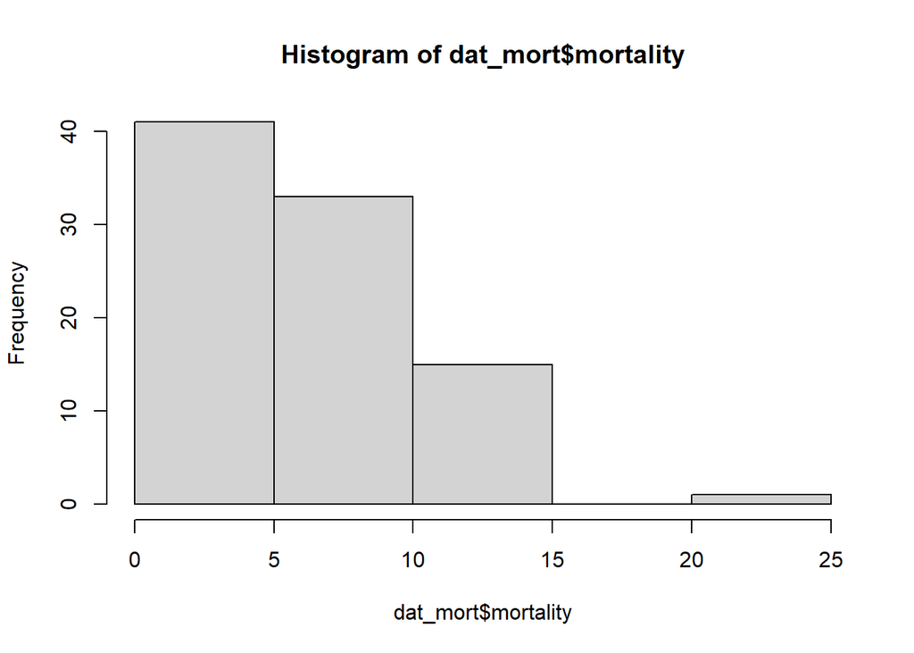

## Reg. lineal múltiple

```
##
## Call:
## lm(formula = mortality ~ ., data = dat_mort)
##
## Residuals:
##     Min      1Q  Median      3Q     Max
## -9.8879 -2.7641 -0.6773  2.2867 10.8777
##
## Coefficients:
##                       Estimate Std. Error t value Pr(>|t|)
## (Intercept)           15.30222    3.95861   3.866 0.000228 ***
## vacination             2.04850    0.80724   2.538 0.013153 *
## prepartum             -0.08371    0.81284  -0.103 0.918235
## experience            -1.88474    0.46931  -4.016 0.000135 ***
## capacitations         -1.65078    0.66408  -2.486 0.015065 *
## rearing_system         1.59171    1.03178   1.543 0.126954
## realiza_calostrado    -0.26763    0.73612  -0.364 0.717161
## calostrum_feeding_num  0.34643    0.89936   0.385 0.701145
## clostrum_feeding_vol  -0.20080    0.52763  -0.381 0.704557
## liquid_feeding_volume -1.79676    0.97904  -1.835 0.070284 .
## hygiene               -1.53697    0.65636  -2.342 0.021751 *
## disease_ranking       -0.11054    0.37215  -0.297 0.767225
## ---
## Signif. codes:  0 '***' 0.001 '**' 0.01 '*' 0.05 '.' 0.1 ' ' 1
##
## Residual standard error: 4.164 on 78 degrees of freedom
## Multiple R-squared:  0.4012, Adjusted R-squared:  0.3168
## F-statistic: 4.751 on 11 and 78 DF,  p-value: 1.506e-05
```

```
## Start:  AIC=267.91
## mortality ~ vacination + prepartum + experience + capacitations +
##     rearing_system + realiza_calostrado + calostrum_feeding_num +
##     clostrum_feeding_vol + liquid_feeding_volume + hygiene +
##     disease_ranking
##
##                         Df Sum of Sq    RSS    AIC
## - prepartum              1     0.184 1352.9 265.92
## - disease_ranking        1     1.530 1354.2 266.01
## - realiza_calostrado     1     2.292 1355.0 266.06
## - clostrum_feeding_vol   1     2.512 1355.2 266.07
## - calostrum_feeding_num  1     2.573 1355.3 266.08
## <none>                               1352.7 267.91
## - rearing_system         1    41.273 1394.0 268.61
## - liquid_feeding_volume  1    58.411 1411.1 269.71
## - hygiene                1    95.096 1447.8 272.02
## - capacitations          1   107.162 1459.9 272.77
## - vacination             1   111.681 1464.4 273.05
## - experience             1   279.706 1632.4 282.82
##
## Step:  AIC=265.92
## mortality ~ vacination + experience + capacitations + rearing_system +
##     realiza_calostrado + calostrum_feeding_num + clostrum_feeding_vol +
##     liquid_feeding_volume + hygiene + disease_ranking
##
##                         Df Sum of Sq    RSS    AIC
## - disease_ranking        1     1.389 1354.3 264.01
## - realiza_calostrado     1     2.257 1355.2 264.07
## - calostrum_feeding_num  1     2.390 1355.3 264.08
## - clostrum_feeding_vol   1     2.482 1355.4 264.08
## <none>                               1352.9 265.92
## - rearing_system         1    42.170 1395.1 266.68
## - liquid_feeding_volume  1    58.773 1411.7 267.75
## + prepartum              1     0.184 1352.7 267.91
## - hygiene                1   106.067 1459.0 270.71
## - capacitations          1   111.484 1464.4 271.04
## - vacination             1   111.637 1464.5 271.05
## - experience             1   285.839 1638.7 281.17
##
## Step:  AIC=264.01
```

[output cut: 57 more lines]

```
##     liquid_feeding_volume + hygiene
##
##                         Df Sum of Sq    RSS    AIC
## <none>                               1360.4 258.42
## - rearing_system         1    43.565 1404.0 259.25
## + realiza_calostrado     1     2.695 1357.7 260.24
## + clostrum_feeding_vol   1     1.621 1358.8 260.31
## + disease_ranking        1     1.206 1359.2 260.34
## + calostrum_feeding_num  1     0.355 1360.1 260.39
## + prepartum              1     0.005 1360.4 260.42
## - liquid_feeding_volume  1    82.063 1442.5 261.69
## - vacination             1   107.708 1468.2 263.27
## - hygiene                1   114.212 1474.7 263.67
## - capacitations          1   135.337 1495.8 264.95
## - experience             1   302.235 1662.7 274.47
```

```
##
## Call:
## lm(formula = mortality ~ vacination + experience + capacitations +
##     rearing_system + liquid_feeding_volume + hygiene, data = dat_mort)
##
## Residuals:
##     Min      1Q  Median      3Q     Max
## -9.6512 -2.6977 -0.7741  2.7653 11.0904
##
## Coefficients:
##                       Estimate Std. Error t value Pr(>|t|)
## (Intercept)            15.3567     3.4916   4.398 3.22e-05 ***
## vacination              1.9459     0.7591   2.563  0.01217 *
## experience             -1.8999     0.4424  -4.294 4.73e-05 ***
## capacitations          -1.7597     0.6124  -2.873  0.00515 **
## rearing_system          1.5556     0.9542   1.630  0.10683
## liquid_feeding_volume  -1.9749     0.8826  -2.238  0.02793 *
## hygiene                -1.5894     0.6021  -2.640  0.00991 **
## ---
## Signif. codes:  0 '***' 0.001 '**' 0.01 '*' 0.05 '.' 0.1 ' ' 1
##
## Residual standard error: 4.049 on 83 degrees of freedom
## Multiple R-squared:  0.3978, Adjusted R-squared:  0.3543
## F-statistic: 9.138 on 6 and 83 DF,  p-value: 1.136e-07
```

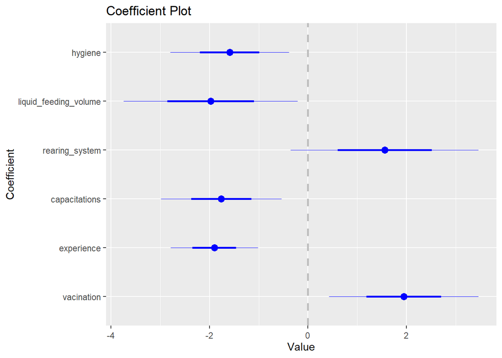

En este grafico podemos ver todas las variables que tienen efecto sobre mortalidad la disminuyen, menos vacunacion la cual muestra que al aumentar la vacunacion aumenta la mortalidad y sistema de crianza que representa el alojamiento de los animales. Preguntar a Lu como armo la tabla..

Analizo la importancia relativa de las variables presentes en el modelo

```
## Response variable: mortality
## Total response variance: 25.3834
## Analysis based on 90 observations
##
## 6 Regressors:
## vacination experience capacitations rearing_system liquid_feeding_volume hygiene
## Proportion of variance explained by model: 39.78%
## Metrics are normalized to sum to 100% (rela=TRUE).
##
## Relative importance metrics:
##
##                             car
## vacination            0.1213761
## experience            0.4196616
## capacitations         0.1481106
## rearing_system        0.0372352
## liquid_feeding_volume 0.1446459
## hygiene               0.1289706
```

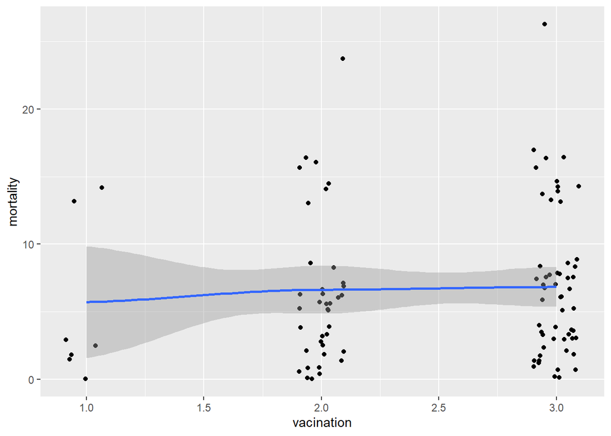

Este ultimo grafico exploratorio muestra que en realidad hay pocos datos para el nivel de vacunacion 1 y a lo mejor ahi esta la explicacion del porque da raro el resultado (>vacunacion>mortalidad)

## Reg log - mort<3. Tansformo la variable mortalidad a binaria (> o < a 3)

```
## Start:  AIC=119.03
## mortality > 3 ~ vacination + prepartum + experience + capacitations +
##     rearing_system + realiza_calostrado + calostrum_feeding_num +
##     clostrum_feeding_vol + liquid_feeding_volume + hygiene +
##     disease_ranking
##
##                         Df Deviance    AIC
## - calostrum_feeding_num  1   14.834 117.15
## - rearing_system         1   14.838 117.17
## - realiza_calostrado     1   14.841 117.19
## - disease_ranking        1   14.900 117.55
## - prepartum              1   15.068 118.56
## - clostrum_feeding_vol   1   15.112 118.82
## <none>                       14.814 119.03
## - hygiene                1   15.422 120.65
## - capacitations          1   15.671 122.09
## - vacination             1   15.716 122.35
## - liquid_feeding_volume  1   15.961 123.74
## - experience             1   16.069 124.35
##
## Step:  AIC=117.15
## mortality > 3 ~ vacination + prepartum + experience + capacitations +
##     rearing_system + realiza_calostrado + clostrum_feeding_vol +
##     liquid_feeding_volume + hygiene + disease_ranking
##
##                         Df Deviance    AIC
## - rearing_system         1   14.859 115.30
## - realiza_calostrado     1   14.869 115.36
## - disease_ranking        1   14.906 115.58
## - prepartum              1   15.069 116.56
## <none>                       14.834 117.15
## - clostrum_feeding_vol   1   15.332 118.12
## - hygiene                1   15.423 118.65
## + calostrum_feeding_num  1   14.814 119.03
## - capacitations          1   15.672 120.10
## - vacination             1   15.751 120.55
## - liquid_feeding_volume  1   15.961 121.74
## - experience             1   16.079 122.40
##
## Step:  AIC=115.3
```

[output cut: 57 more lines]

```
##     liquid_feeding_volume + hygiene
##
##                         Df Deviance    AIC
## <none>                       15.194 111.31
## - clostrum_feeding_vol   1   15.553 111.41
## + prepartum              1   14.949 111.85
## - hygiene                1   15.652 111.98
## + rearing_system         1   15.129 112.92
## + realiza_calostrado     1   15.170 113.16
## + disease_ranking        1   15.173 113.18
## + calostrum_feeding_num  1   15.194 113.31
## - capacitations          1   15.972 113.80
## - vacination             1   16.266 115.44
## - experience             1   16.311 115.69
## - liquid_feeding_volume  1   16.352 115.92
```

```
##
## Call:
## glm(formula = mortality > 3 ~ vacination + experience + capacitations +
##     clostrum_feeding_vol + liquid_feeding_volume + hygiene, data = dat_mort)
##
## Coefficients:
##                       Estimate Std. Error t value Pr(>|t|)
## (Intercept)            1.65541    0.33639   4.921  4.3e-06 ***
## vacination             0.19393    0.08012   2.421   0.0177 *
## experience            -0.11634    0.04710  -2.470   0.0156 *
## capacitations         -0.13476    0.06537  -2.062   0.0424 *
## clostrum_feeding_vol  -0.06148    0.04386  -1.402   0.1647
## liquid_feeding_volume -0.24862    0.09886  -2.515   0.0138 *
## hygiene               -0.10080    0.06374  -1.581   0.1176
## ---
## Signif. codes:  0 '***' 0.001 '**' 0.01 '*' 0.05 '.' 0.1 ' ' 1
##
## (Dispersion parameter for gaussian family taken to be 0.1830585)
##
##     Null deviance: 22.322  on 89  degrees of freedom
## Residual deviance: 15.194  on 83  degrees of freedom
## AIC: 111.31
##
## Number of Fisher Scoring iterations: 2
```

|  | mortality>3 |  |  |
| --- | --- | --- | --- |
| Predictors | Estimates | CI | p |
| (Intercept) | 1.66 | 1.00 – 2.31 | **<0.001** |
| vacination | 0.19 | 0.04 – 0.35 | **0.015** |
| experience | -0.12 | -0.21 – -0.02 | **0.014** |
| capacitations | -0.13 | -0.26 – -0.01 | **0.039** |
| clostrum feeding vol | -0.06 | -0.15 – 0.02 | 0.161 |
| liquid feeding volume | -0.25 | -0.44 – -0.05 | **0.012** |
| hygiene | -0.10 | -0.23 – 0.02 | 0.114 |
| Observations | 90 |  |  |
| R<sup>2</sup> | -1.237 |  |  |

Cuando corremos el modelo con mortalidad como binaria, sale del modelo el sistema de alojamiento e ingresa la variable volumen de calostro consumido antes de las 24 hs. Esta variable si bien no tiene efecto, si es importante para el odelo y por eso la ingresa, higiene en este caso pierde su nivel de significancia pero permanece en el modelo.

```
## $odds_data
## # A tibble: 6 × 4
##      OR lower upper vars
##   <dbl> <dbl> <dbl> <chr>
## 1 1.21  1.04  1.42  vacination
## 2 0.890 0.812 0.976 experience
## 3 0.874 0.769 0.993 capacitations
## 4 0.940 0.863 1.02  clostrum_feeding_vol
## 5 0.780 0.643 0.947 liquid_feeding_volume
## 6 0.904 0.798 1.02  hygiene
##
## $odds_plot
```

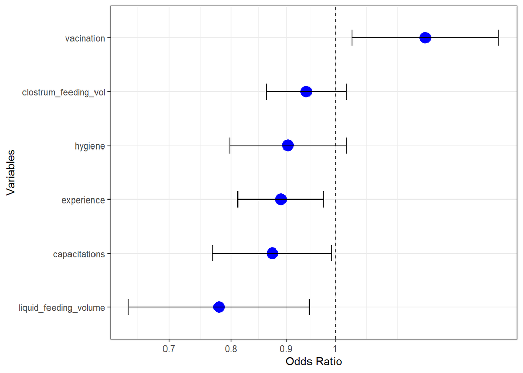

###Odds ratio

```
##
## Call:
## glm(formula = mortality > 3 ~ ., family = binomial, data = dat_mort)
##
## Coefficients:
##                       Estimate Std. Error z value Pr(>|z|)
## (Intercept)             5.6040     2.6006   2.155   0.0312 *
## vacination              1.0751     0.5105   2.106   0.0352 *
## prepartum               0.5249     0.4918   1.067   0.2858
## experience             -0.7246     0.2934  -2.470   0.0135 *
## capacitations          -0.8234     0.3949  -2.085   0.0370 *
## rearing_system          0.3129     0.6573   0.476   0.6340
## realiza_calostrado      0.2061     0.4726   0.436   0.6628
## calostrum_feeding_num  -0.2219     0.5176  -0.429   0.6681
## clostrum_feeding_vol   -0.4327     0.3055  -1.417   0.1566
## liquid_feeding_volume  -1.3834     0.5682  -2.435   0.0149 *
## hygiene                -0.8215     0.4347  -1.890   0.0588 .
## disease_ranking         0.1208     0.2129   0.567   0.5705
## ---
## Signif. codes:  0 '***' 0.001 '**' 0.01 '*' 0.05 '.' 0.1 ' ' 1
##
## (Dispersion parameter for binomial family taken to be 1)
##
##     Null deviance: 124.054  on 89  degrees of freedom
## Residual deviance:  88.211  on 78  degrees of freedom
## AIC: 112.21
##
## Number of Fisher Scoring iterations: 5
```

|  | mortality>3 |  |  |
| --- | --- | --- | --- |
| Predictors | Odds Ratios | CI | p |
| (Intercept) | 271.50 | 2.23 – 68012.87 | **0.031** |
| vacination | 2.93 | 1.12 – 8.55 | **0.035** |
| prepartum | 1.69 | 0.66 – 4.68 | 0.286 |
| experience | 0.48 | 0.26 – 0.83 | **0.014** |
| capacitations | 0.44 | 0.19 – 0.93 | **0.037** |
| rearing system | 1.37 | 0.37 – 5.15 | 0.634 |
| realiza calostrado | 1.23 | 0.49 – 3.20 | 0.663 |
| calostrum feeding num | 0.80 | 0.28 – 2.18 | 0.668 |
| clostrum feeding vol | 0.65 | 0.35 – 1.17 | 0.157 |
| liquid feeding volume | 0.25 | 0.08 – 0.75 | **0.015** |
| hygiene | 0.44 | 0.18 – 0.99 | 0.059 |
| disease ranking | 1.13 | 0.75 – 1.74 | 0.571 |
| Observations | 90 |  |  |
| R<sup>2</sup> Tjur | 0.320 |  |  |

```
## $odds_data
## # A tibble: 11 × 4
##       OR  lower upper vars
##    <dbl>  <dbl> <dbl> <chr>
##  1 2.93  1.12   8.55  vacination
##  2 1.69  0.659  4.68  prepartum
##  3 0.485 0.259  0.833 experience
##  4 0.439 0.193  0.929 capacitations
##  5 1.37  0.374  5.15  rearing_system
##  6 1.23  0.488  3.20  realiza_calostrado
##  7 0.801 0.280  2.18  calostrum_feeding_num
##  8 0.649 0.348  1.17  clostrum_feeding_vol
##  9 0.251 0.0784 0.749 liquid_feeding_volume
## 10 0.440 0.177  0.993 hygiene
## 11 1.13  0.747  1.74  disease_ranking
##
## $odds_plot
```

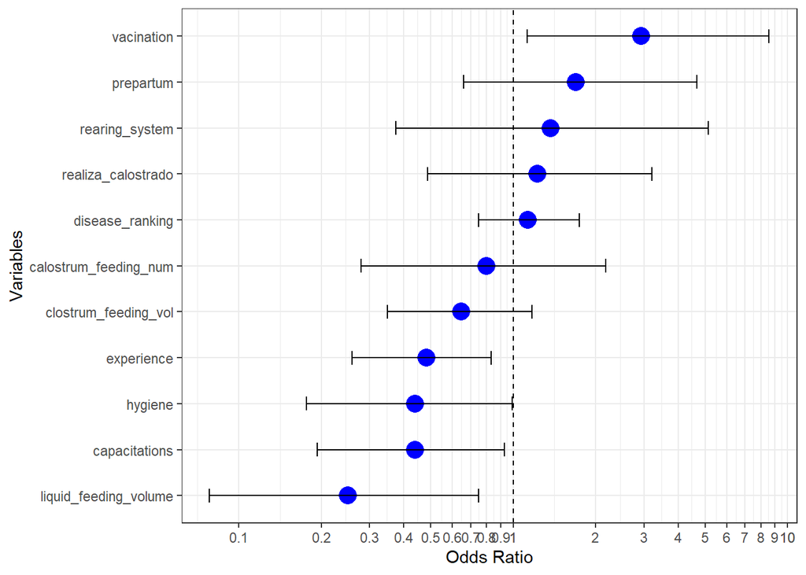

## Árbol de clasificación

```
## n= 90
##
## node), split, n, deviance, yval
##       * denotes terminal node
##
##  1) root 90 2259.12200  6.255556
##    2) experience>=2.5 59  880.16950  4.881356
##      4) hygiene>=1.5 48  506.31250  4.312500
##        8) capacitations>=1.5 20  105.00000  3.500000
##         16) hygiene>=2.5 11   22.72727  2.454545 *
##         17) hygiene< 2.5 9   55.55556  4.777778 *
##        9) capacitations< 1.5 28  378.67860  4.892857
##         18) liquid_feeding_volume>=2.5 15  191.73330  3.866667 *
##         19) liquid_feeding_volume< 2.5 13  152.92310  6.076923 *
##      5) hygiene< 1.5 11  290.54550  7.363636 *
##    3) experience< 2.5 31 1055.48400  8.870968
##      6) capacitations>=1.5 14  316.92860  6.928571 *
##      7) capacitations< 1.5 17  642.23530 10.470590 *
```

```
## Call:
## rpart(formula = mortality ~ liquid_feeding_volume + hygiene +
##     capacitations + experience, data = dat_mort)
##   n= 90
##
##           CP nsplit rel error    xerror      xstd
## 1 0.14318343      0 1.0000000 1.0197061 0.1826590
## 2 0.04263603      1 0.8568166 0.9918205 0.2212887
## 3 0.03687784      2 0.8141805 1.1112875 0.2277275
## 4 0.01253940      3 0.7773027 1.0361482 0.2224276
## 5 0.01182635      5 0.7522239 1.0503583 0.2228558
## 6 0.01000000      6 0.7403976 1.0542625 0.2235279
##
## Variable importance
##            experience         capacitations               hygiene
##                    53                    21                    21
## liquid_feeding_volume
##                     6
##
## Node number 1: 90 observations,    complexity param=0.1431834
##   mean=6.255556, MSE=25.10136
##   left son=2 (59 obs) right son=3 (31 obs)
##   Primary splits:
##       experience            < 2.5 to the right, improve=0.14318340, (0 missing)
##       liquid_feeding_volume < 2.5 to the right, improve=0.09872084, (0 missing)
##       hygiene               < 1.5 to the right, improve=0.06786700, (0 missing)
##       capacitations         < 1.5 to the right, improve=0.04769934, (0 missing)
##
## Node number 2: 59 observations,    complexity param=0.03687784
##   mean=4.881356, MSE=14.91813
##   left son=4 (48 obs) right son=5 (11 obs)
##   Primary splits:
##       hygiene               < 1.5 to the right, improve=0.09465397, (0 missing)
##       liquid_feeding_volume < 2.5 to the right, improve=0.07195382, (0 missing)
##       capacitations         < 1.5 to the right, improve=0.05587464, (0 missing)
##       experience            < 3.5 to the right, improve=0.01711881, (0 missing)
##
## Node number 3: 31 observations,    complexity param=0.04263603
##   mean=8.870968, MSE=34.04787
##   left son=6 (14 obs) right son=7 (17 obs)
```

[output cut: 40 more lines]

```
##       hygiene               < 2.5 to the left,  improve=0.01509461, (0 missing)
##   Surrogate splits:
##       hygiene < 2.5 to the right, agree=0.571, adj=0.077, (0 split)
##
## Node number 16: 11 observations
##   mean=2.454545, MSE=2.066116
##
## Node number 17: 9 observations
##   mean=4.777778, MSE=6.17284
##
## Node number 18: 15 observations
##   mean=3.866667, MSE=12.78222
##
## Node number 19: 13 observations
##   mean=6.076923, MSE=11.76331
```

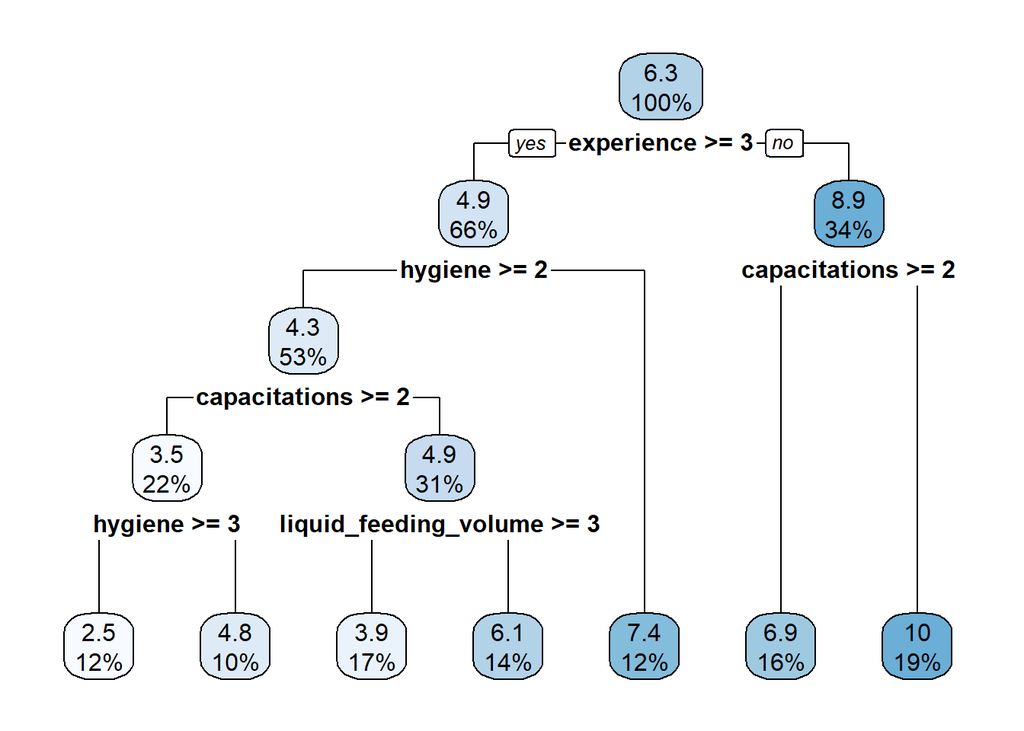

Clasifica los casos. - las particiones que aparecen arriba son las que capturan mayor variabilidad - vas particionando en grupos menores, mas chicos, con menos variablidad - irian en linea con variable importance La media de mortalidad de todas las encuestas es de 6.3%. Si experiencia es mayor o igual a 3, el promedio de mortalidad es 4.9%, y si a su vez capacitacion es mayor igual a 2, tiene un 3.5% en promedio. A su vex si las practicas de higiene son >=3 la mortalidad se reduce al 2,5%.

- Importancia de las variables predictoras sobre mortalidad

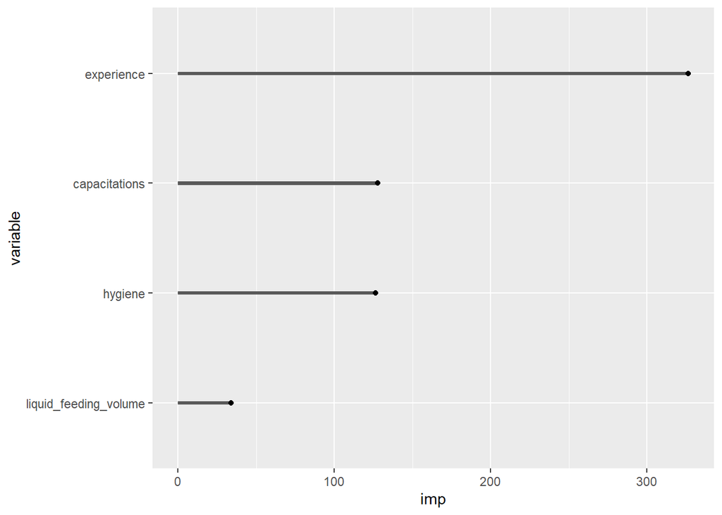

## Random forest

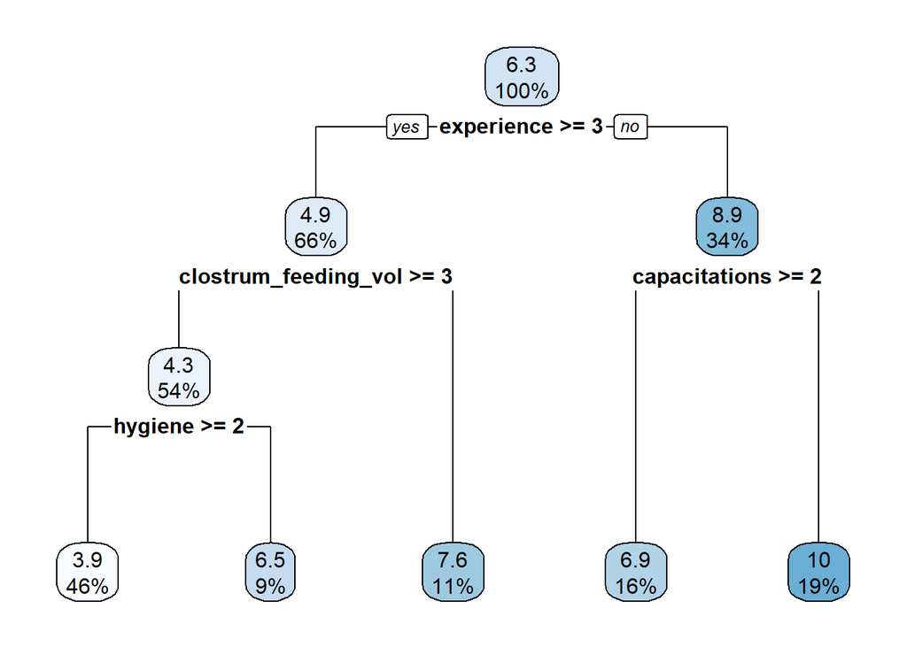

```
## mortality is  3.9 when
##     experience >= 3
##     clostrum_feeding_vol >= 3
##     hygiene >= 2
##
## mortality is  6.5 when
##     experience >= 3
##     clostrum_feeding_vol >= 3
##     hygiene < 2
##
## mortality is  6.9 when
##     experience < 3
##     capacitations >= 2
##
## mortality is  7.6 when
##     experience >= 3
##     clostrum_feeding_vol < 3
##
## mortality is 10.5 when
##     experience < 3
##     capacitations < 2
```

```
##           experience clostrum_feeding_vol        capacitations
##                 50.0                 18.0                 14.9
##              hygiene   realiza_calostrado            prepartum
##                  9.1                  3.7                  3.2
##           vacination
##                  1.1
```

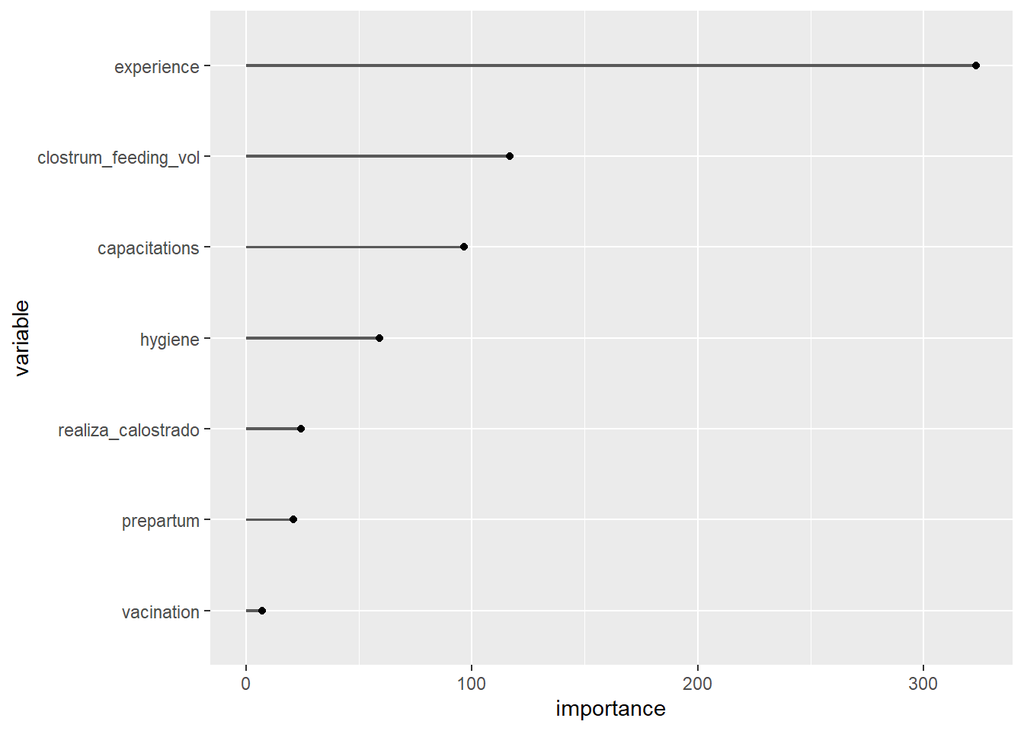

## Factorizo variables predictoras

Si factorizo las variables predictoras, el modelo queda de la siguiente forma:

Data summary

| Name | Piped data |
| --- | --- |
| Number of rows | 90 |
| Number of columns | 11 |
| _______________________ |  |
| Column type frequency: |  |
| factor | 10 |
| numeric | 1 |
| ________________________ |  |
| Group variables | None |

**Variable type: factor**

| skim_variable | n_missing | complete_rate | ordered | n_unique | top_counts |
| --- | --- | --- | --- | --- | --- |
| prepartum | 0 | 1 | FALSE | 3 | 3: 42, 2: 41, 1: 7 |
| experience | 0 | 1 | FALSE | 4 | 4: 49, 2: 25, 3: 10, 1: 6 |
| capacitations | 0 | 1 | FALSE | 3 | 1: 53, 2: 23, 3: 14 |
| rearing_system | 0 | 1 | FALSE | 3 | 2: 60, 1: 16, 2.5: 14 |
| realiza_calostrado | 0 | 1 | FALSE | 3 | 2: 49, 1: 28, 3: 13 |
| calostrum_feeding_num | 0 | 1 | FALSE | 3 | 1: 44, 2: 38, 3: 8 |
| clostrum_feeding_vol | 0 | 1 | FALSE | 5 | 4: 30, 3: 21, 2: 17, 5: 17 |
| liquid_feeding_volume | 0 | 1 | FALSE | 3 | 2: 55, 3: 34, 1: 1 |
| hygiene | 0 | 1 | FALSE | 3 | 3: 40, 2: 34, 1: 16 |
| disease_ranking | 0 | 1 | FALSE | 5 | 1: 58, 4: 10, 3: 9, 5: 7 |

**Variable type: numeric**

| skim_variable | n_missing | complete_rate | mean | sd | p0 | p25 | p50 | p75 | p100 | hist |
| --- | --- | --- | --- | --- | --- | --- | --- | --- | --- | --- |
| mortality | 0 | 1 | 6.26 | 5.04 | 2 | 2 | 7 | 7 | 25 | ▇▆▃▁▁ |

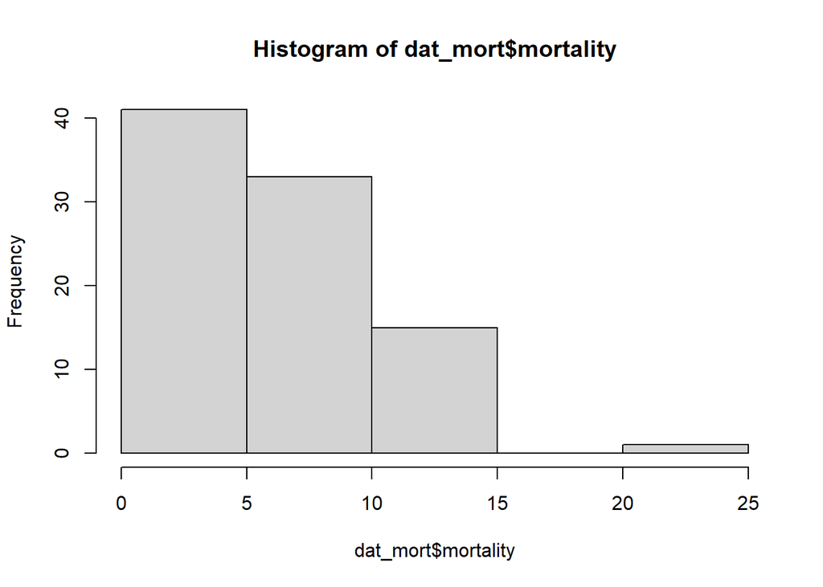

## Reg. lineal múltiple

```
## Analysis of Variance Table
##
## Response: mortality
##                       Df  Sum Sq Mean Sq F value    Pr(>F)
## prepartum              2  155.39  77.694  4.2217   0.01896 *
## experience             3  460.87 153.624  8.3475 9.145e-05 ***
## capacitations          2  163.73  81.867  4.4484   0.01553 *
## rearing_system         2   71.53  35.763  1.9433   0.15159
## realiza_calostrado     2   20.85  10.423  0.5664   0.57041
## calostrum_feeding_num  2    3.55   1.776  0.0965   0.90813
## clostrum_feeding_vol   4   76.10  19.025  1.0338   0.39678
## liquid_feeding_volume  2   48.92  24.458  1.3290   0.27195
## hygiene                2   41.03  20.513  1.1146   0.33432
## disease_ranking        4   39.34   9.834  0.5344   0.71094
## Residuals             64 1177.83  18.404
## ---
## Signif. codes:  0 '***' 0.001 '**' 0.01 '*' 0.05 '.' 0.1 ' ' 1
```

```
## Start:  AIC=283.45
## mortality ~ prepartum + experience + capacitations + rearing_system +
##     realiza_calostrado + calostrum_feeding_num + clostrum_feeding_vol +
##     liquid_feeding_volume + hygiene + disease_ranking
##
##                         Df Sum of Sq    RSS    AIC
## - clostrum_feeding_vol   4    37.173 1215.0 278.24
## - disease_ranking        4    39.337 1217.2 278.40
## - calostrum_feeding_num  2     9.446 1187.3 280.16
## - realiza_calostrado     2    10.075 1187.9 280.21
## - rearing_system         2    28.254 1206.1 281.58
## - hygiene                2    33.567 1211.4 281.98
## - prepartum              2    46.382 1224.2 282.92
## <none>                               1177.8 283.45
## - liquid_feeding_volume  2    57.409 1235.2 283.73
## - capacitations          2   134.928 1312.8 289.21
## - experience             3   236.060 1413.9 293.89
##
## Step:  AIC=278.24
## mortality ~ prepartum + experience + capacitations + rearing_system +
##     realiza_calostrado + calostrum_feeding_num + liquid_feeding_volume +
##     hygiene + disease_ranking
##
##                         Df Sum of Sq    RSS    AIC
## - disease_ranking        4    43.682 1258.7 273.42
## - calostrum_feeding_num  2     3.096 1218.1 274.47
## - realiza_calostrado     2    14.229 1229.2 275.29
## - prepartum              2    38.385 1253.4 277.04
## - rearing_system         2    39.383 1254.4 277.11
## <none>                               1215.0 278.24
## - hygiene                2    57.300 1272.3 278.39
## - liquid_feeding_volume  2    64.496 1279.5 278.90
## + clostrum_feeding_vol   4    37.173 1177.8 283.45
## - capacitations          2   146.137 1361.1 284.46
## - experience             3   286.582 1501.6 291.30
##
## Step:  AIC=273.42
## mortality ~ prepartum + experience + capacitations + rearing_system +
##     realiza_calostrado + calostrum_feeding_num + liquid_feeding_volume +
##     hygiene
```

[output cut: 49 more lines]

```
## mortality ~ experience + capacitations + rearing_system + liquid_feeding_volume +
##     hygiene
##
##                         Df Sum of Sq    RSS    AIC
## <none>                               1322.8 265.89
## + prepartum              2     47.89 1274.9 266.57
## - rearing_system         2     74.04 1396.8 266.79
## - hygiene                2     91.55 1414.3 267.91
## - liquid_feeding_volume  2    100.27 1423.0 268.47
## + realiza_calostrado     2     13.87 1308.9 268.94
## + calostrum_feeding_num  2      6.87 1315.9 269.42
## - capacitations          2    125.46 1448.2 270.05
## + disease_ranking        4     44.48 1278.3 270.81
## + clostrum_feeding_vol   4     32.71 1290.1 271.64
## - experience             3    383.59 1706.4 282.81
```

```
## Analysis of Variance Table
##
## Response: mortality
##                       Df  Sum Sq Mean Sq F value    Pr(>F)
## experience             3  475.83 158.609  9.3527 2.362e-05 ***
## capacitations          2  160.74  80.371  4.7392   0.01142 *
## rearing_system         2  102.95  51.474  3.0353   0.05377 .
## liquid_feeding_volume  2  105.28  52.639  3.1040   0.05046 .
## hygiene                2   91.55  45.775  2.6992   0.07354 .
## Residuals             78 1322.78  16.959
## ---
## Signif. codes:  0 '***' 0.001 '**' 0.01 '*' 0.05 '.' 0.1 ' ' 1
```

Se puede ver que en el modelo sale la variable vacunacion al preparto, y ejersen efecto sobre mortalidad la experiencia y capacitaciones del personal, mientras que el sistema de alojamiento de los terneros, volumen de dieta liquida e higiene presentan una tendencia sobre la mortalidad.

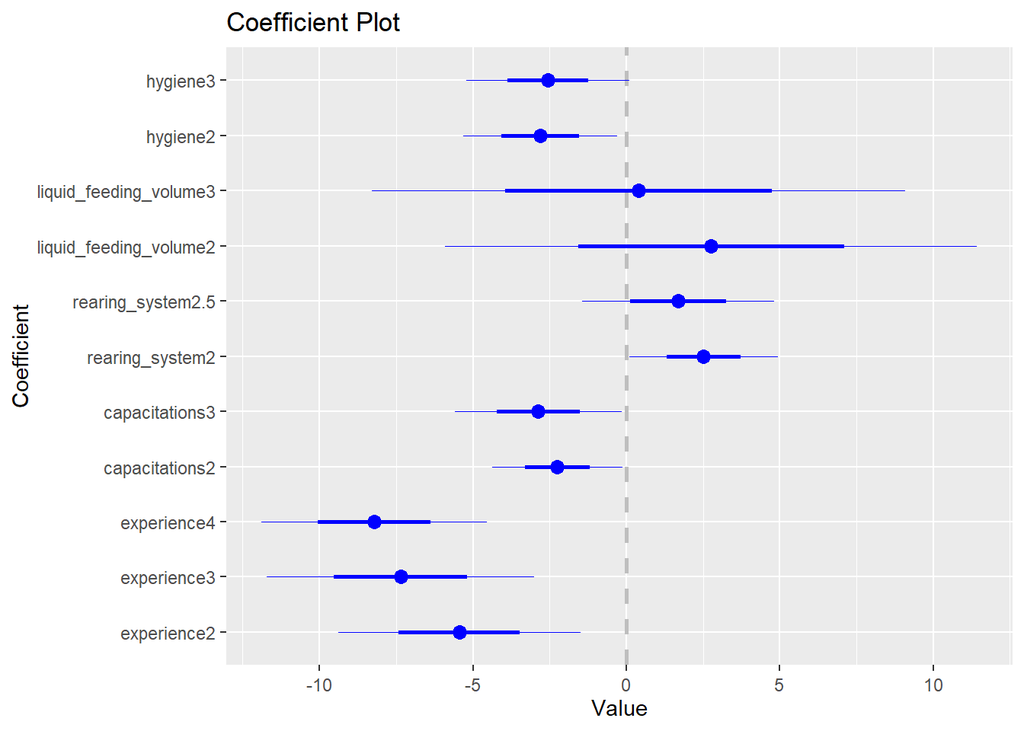

## Reg log - mort<3. Tansformo la variable mortalidad a binaria (> o < a 3)

```
## Analysis of Deviance Table (Type II tests)
##
## Response: mortality >= 3
##                       LR Chisq Df Pr(>Chisq)
## prepartum               3.1871  2    0.20320
## experience              7.3289  3    0.06212 .
## capacitations           3.9012  2    0.14219
## rearing_system          0.7923  2    0.67292
## realiza_calostrado      0.8524  2    0.65298
## calostrum_feeding_num   2.4138  2    0.29912
## clostrum_feeding_vol    1.0180  4    0.90705
## liquid_feeding_volume   4.7199  2    0.09443 .
## hygiene                 0.6582  2    0.71955
## disease_ranking         3.3524  4    0.50067
## ---
## Signif. codes:  0 '***' 0.001 '**' 0.01 '*' 0.05 '.' 0.1 ' ' 1
```

```
## Start:  AIC=132.58
## mortality >= 3 ~ prepartum + experience + capacitations + rearing_system +
##     realiza_calostrado + calostrum_feeding_num + clostrum_feeding_vol +
##     liquid_feeding_volume + hygiene + disease_ranking
##
##                         Df Deviance    AIC
## - clostrum_feeding_vol   4   12.817 126.00
## - disease_ranking        4   13.277 129.17
## - hygiene                2   12.746 129.50
## - rearing_system         2   12.773 129.68
## - realiza_calostrado     2   12.784 129.77
## - calostrum_feeding_num  2   13.092 131.91
## <none>                       12.617 132.58
## - prepartum              2   13.245 132.95
## - capacitations          2   13.386 133.90
## - liquid_feeding_volume  2   13.547 134.98
## - experience             3   14.061 136.33
##
## Step:  AIC=126
## mortality >= 3 ~ prepartum + experience + capacitations + rearing_system +
##     realiza_calostrado + calostrum_feeding_num + liquid_feeding_volume +
##     hygiene + disease_ranking
##
##                         Df Deviance    AIC
## - rearing_system         2   12.970 123.06
## - hygiene                2   12.977 123.11
## - realiza_calostrado     2   12.995 123.24
## - disease_ranking        4   13.594 123.29
## - calostrum_feeding_num  2   13.363 125.75
## <none>                       12.817 126.00
## - prepartum              2   13.491 126.61
## - capacitations          2   13.813 128.73
## - liquid_feeding_volume  2   13.956 129.66
## - experience             3   14.363 130.24
## + clostrum_feeding_vol   4   12.617 132.58
##
## Step:  AIC=123.06
## mortality >= 3 ~ prepartum + experience + capacitations + realiza_calostrado +
##     calostrum_feeding_num + liquid_feeding_volume + hygiene +
##     disease_ranking
```

[output cut: 65 more lines]

```
## Step:  AIC=115.77
## mortality >= 3 ~ prepartum + experience + capacitations + liquid_feeding_volume
##
##                         Df Deviance    AIC
## <none>                       14.937 115.77
## + rearing_system         2   14.342 116.11
## - prepartum              2   15.712 116.32
## + calostrum_feeding_num  2   14.385 116.38
## - capacitations          2   15.798 116.81
## + disease_ranking        4   13.908 117.35
## + realiza_calostrado     2   14.689 118.27
## + hygiene                2   14.734 118.54
## + clostrum_feeding_vol   4   14.547 121.39
## - liquid_feeding_volume  2   16.639 121.48
## - experience             3   17.247 122.71
```

```
## Analysis of Deviance Table (Type II tests)
##
## Response: mortality >= 3
##                       LR Chisq Df Pr(>Chisq)
## prepartum               4.1518  2   0.125445
## experience             12.3754  3   0.006202 **
## capacitations           4.6133  2   0.099596 .
## liquid_feeding_volume   9.1185  2   0.010470 *
## ---
## Signif. codes:  0 '***' 0.001 '**' 0.01 '*' 0.05 '.' 0.1 ' ' 1
```

```
##
## Call:
## glm(formula = mortality >= 3 ~ prepartum + experience + capacitations +
##     liquid_feeding_volume, data = dat_mort)
##
## Coefficients:
##                        Estimate Std. Error t value Pr(>|t|)
## (Intercept)             0.21972    0.50777   0.433   0.6664
## prepartum2              0.37774    0.18846   2.004   0.0484 *
## prepartum3              0.28156    0.18491   1.523   0.1318
## experience2            -0.27711    0.20069  -1.381   0.1712
## experience3            -0.06204    0.22536  -0.275   0.7838
## experience4            -0.48034    0.19156  -2.508   0.0142 *
## capacitations2         -0.11712    0.11096  -1.056   0.2944
## capacitations3         -0.27886    0.13471  -2.070   0.0417 *
## liquid_feeding_volume2  0.55870    0.44818   1.247   0.2162
## liquid_feeding_volume3  0.26077    0.45197   0.577   0.5656
## ---
## Signif. codes:  0 '***' 0.001 '**' 0.01 '*' 0.05 '.' 0.1 ' ' 1
##
## (Dispersion parameter for gaussian family taken to be 0.1867074)
##
##     Null deviance: 22.322  on 89  degrees of freedom
## Residual deviance: 14.937  on 80  degrees of freedom
## AIC: 115.77
##
## Number of Fisher Scoring iterations: 2
```

|  | mortality>=3 |  |  |
| --- | --- | --- | --- |
| Predictors | Estimates | CI | p |
| (Intercept) | 0.22 | -0.78 – 1.21 | 0.665 |
| prepartum [2] | 0.38 | 0.01 – 0.75 | **0.045** |
| prepartum [3] | 0.28 | -0.08 – 0.64 | 0.128 |
| experience [2] | -0.28 | -0.67 – 0.12 | 0.167 |
| experience [3] | -0.06 | -0.50 – 0.38 | 0.783 |
| experience [4] | -0.48 | -0.86 – -0.10 | **0.012** |
| capacitations [2] | -0.12 | -0.33 – 0.10 | 0.291 |
| capacitations [3] | -0.28 | -0.54 – -0.01 | **0.038** |
| liquid feeding volume [2] | 0.56 | -0.32 – 1.44 | 0.213 |
| liquid feeding volume [3] | 0.26 | -0.63 – 1.15 | 0.564 |
| Observations | 90 |  |  |
| R<sup>2</sup> | -1.242 |  |  |

Cuando corremos el modelo con mortalidad como binaria, sale del modelo el sistema de alojamiento e ingresa la variable volumen de dieta liquida. Las caracteristicas del sector preparto ingresan al modelo, si bien no tienen significancia, si es importante para el modelo y por eso la ingresa.

```
## $odds_data
## # A tibble: 9 × 4
##      OR lower upper vars
##   <dbl> <dbl> <dbl> <chr>
## 1 1.46  1.01  2.11  prepartum2
## 2 1.33  0.922 1.90  prepartum3
## 3 0.758 0.511 1.12  experience2
## 4 0.940 0.604 1.46  experience3
## 5 0.619 0.425 0.900 experience4
## 6 0.889 0.716 1.11  capacitations2
## 7 0.757 0.581 0.985 capacitations3
## 8 1.75  0.726 4.21  liquid_feeding_volume2
## 9 1.30  0.535 3.15  liquid_feeding_volume3
##
## $odds_plot
```

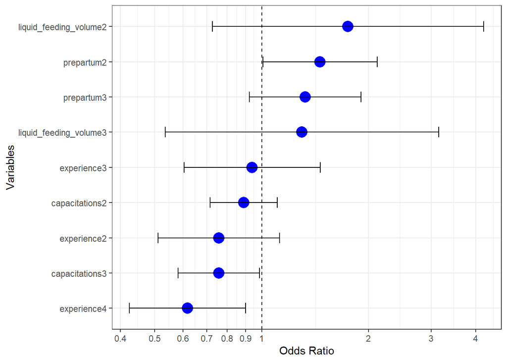

###Odds ratio

```
##
## Call:
## glm(formula = mortality > 3 ~ ., family = binomial, data = dat_mort)
##
## Coefficients:
##                          Estimate Std. Error z value Pr(>|z|)
## (Intercept)             -12.98564 1455.39989  -0.009   0.9929
## prepartum2                3.66491    1.71006   2.143   0.0321 *
## prepartum3                3.28273    1.70823   1.922   0.0546 .
## experience2              -2.28907    1.54099  -1.485   0.1374
## experience3              -0.07456    1.83947  -0.041   0.9677
## experience4              -3.55491    1.49836  -2.373   0.0177 *
## capacitations2           -0.96541    0.86384  -1.118   0.2637
## capacitations3           -2.24485    1.12487  -1.996   0.0460 *
## rearing_system2           1.29152    1.01102   1.277   0.2014
## rearing_system2.5         0.09197    1.19116   0.077   0.9385
## realiza_calostrado2       0.14923    0.93544   0.160   0.8733
## realiza_calostrado3       0.70284    1.14937   0.612   0.5409
## calostrum_feeding_num2    0.73480    0.87194   0.843   0.3994
## calostrum_feeding_num3   -1.73923    1.89184  -0.919   0.3579
## clostrum_feeding_vol2    -1.50589    1.92014  -0.784   0.4329
## clostrum_feeding_vol3    -1.49711    1.85569  -0.807   0.4198
## clostrum_feeding_vol4    -2.29831    1.91535  -1.200   0.2302
## clostrum_feeding_vol5    -1.88862    2.23483  -0.845   0.3981
## liquid_feeding_volume2   14.84773 1455.39808   0.010   0.9919
## liquid_feeding_volume3   13.15913 1455.39815   0.009   0.9928
## hygiene2                 -0.66912    1.09040  -0.614   0.5394
## hygiene3                 -0.86745    1.18629  -0.731   0.4646
## disease_ranking2          2.90376    1.80823   1.606   0.1083
## disease_ranking3         -1.88763    1.43057  -1.319   0.1870
## disease_ranking4          0.94809    1.09083   0.869   0.3848
## disease_ranking5          0.32166    1.61816   0.199   0.8424
## ---
## Signif. codes:  0 '***' 0.001 '**' 0.01 '*' 0.05 '.' 0.1 ' ' 1
##
## (Dispersion parameter for binomial family taken to be 1)
##
##     Null deviance: 124.054  on 89  degrees of freedom
## Residual deviance:  71.861  on 64  degrees of freedom
## AIC: 123.86
##
## Number of Fisher Scoring iterations: 14
```

|  | mortality>3 |  |  |
| --- | --- | --- | --- |
| Predictors | Odds Ratios | CI | p |
| (Intercept) | 0.00 | NA – 885189861216781077524046480820426828280244624626668602062026282664400082068622244.00 | 0.993 |
| prepartum [2] | 39.05 | 1.67 – 1549.54 | **0.032** |
| prepartum [3] | 26.65 | 1.12 – 1058.94 | 0.055 |
| experience [2] | 0.10 | 0.00 – 1.59 | 0.137 |
| experience [3] | 0.93 | 0.02 – 44.91 | 0.968 |
| experience [4] | 0.03 | 0.00 – 0.40 | **0.018** |
| capacitations [2] | 0.38 | 0.06 – 2.03 | 0.264 |
| capacitations [3] | 0.11 | 0.01 – 0.89 | **0.046** |
| rearing system [2] | 3.64 | 0.51 – 29.49 | 0.201 |
| rearing system [2.5] | 1.10 | 0.10 – 12.09 | 0.938 |
| realiza calostrado [2] | 1.16 | 0.18 – 7.62 | 0.873 |
| realiza calostrado [3] | 2.02 | 0.22 – 21.89 | 0.541 |
| calostrum feeding num [2] | 2.09 | 0.40 – 13.08 | 0.399 |
| calostrum feeding num [3] | 0.18 | 0.00 – 5.86 | 0.358 |
| clostrum feeding vol [2] | 0.22 | 0.00 – 8.07 | 0.433 |
| clostrum feeding vol [3] | 0.22 | 0.00 – 7.24 | 0.420 |
| clostrum feeding vol [4] | 0.10 | 0.00 – 3.54 | 0.230 |
| clostrum feeding vol [5] | 0.15 | 0.00 – 11.35 | 0.398 |
| liquid feeding volume [2] | 2807291.35 | 0.00 – NA | 0.992 |
| liquid feeding volume [3] | 518727.67 | 0.00 – NA | 0.993 |
| hygiene [2] | 0.51 | 0.05 – 4.08 | 0.539 |
| hygiene [3] | 0.42 | 0.03 – 4.08 | 0.465 |
| disease ranking [2] | 18.24 | 0.70 – 853.28 | 0.108 |
| disease ranking [3] | 0.15 | 0.01 – 2.04 | 0.187 |
| disease ranking [4] | 2.58 | 0.34 – 28.97 | 0.385 |
| disease ranking [5] | 1.38 | 0.07 – 46.49 | 0.842 |
| Observations | 90 |  |  |
| R<sup>2</sup> Tjur | 0.439 |  |  |

QUEDA RARO ESTE ODDS!!!!!!!!!!!!!!!!!!

## Árbol de clasificación

```
## n= 90
##
## node), split, n, deviance, yval
##       * denotes terminal node
##
##  1) root 90 2259.12200  6.255556
##    2) experience=3,4 59  880.16950  4.881356
##      4) hygiene=2,3 48  506.31250  4.312500
##        8) capacitations=2,3 20  105.00000  3.500000
##         16) hygiene=3 11   22.72727  2.454545 *
##         17) hygiene=2 9   55.55556  4.777778 *
##        9) capacitations=1 28  378.67860  4.892857
##         18) liquid_feeding_volume=3 15  191.73330  3.866667 *
##         19) liquid_feeding_volume=2 13  152.92310  6.076923 *
##      5) hygiene=1 11  290.54550  7.363636 *
##    3) experience=1,2 31 1055.48400  8.870968
##      6) capacitations=2,3 14  316.92860  6.928571 *
##      7) capacitations=1 17  642.23530 10.470590 *
```

```
## Call:
## rpart(formula = mortality ~ liquid_feeding_volume + hygiene +
##     capacitations + experience, data = dat_mort)
##   n= 90
##
##           CP nsplit rel error   xerror      xstd
## 1 0.14318343      0 1.0000000 1.016660 0.1850423
## 2 0.04263603      1 0.8568166 1.000755 0.2276053
## 3 0.03687784      2 0.8141805 1.134996 0.2321522
## 4 0.01253940      3 0.7773027 1.041150 0.2275741
## 5 0.01182635      5 0.7522239 1.044613 0.2275425
## 6 0.01000000      6 0.7403976 1.044130 0.2276378
##
## Variable importance
##            experience         capacitations               hygiene
##                    53                    21                    21
## liquid_feeding_volume
##                     6
##
## Node number 1: 90 observations,    complexity param=0.1431834
##   mean=6.255556, MSE=25.10136
##   left son=2 (59 obs) right son=3 (31 obs)
##   Primary splits:
##       experience            splits as  RRLL, improve=0.14318340, (0 missing)
##       liquid_feeding_volume splits as  LRL,  improve=0.11011750, (0 missing)
##       hygiene               splits as  RLL,  improve=0.06786700, (0 missing)
##       capacitations         splits as  RLL,  improve=0.04769934, (0 missing)
##
## Node number 2: 59 observations,    complexity param=0.03687784
##   mean=4.881356, MSE=14.91813
##   left son=4 (48 obs) right son=5 (11 obs)
##   Primary splits:
##       hygiene               splits as  RLL,  improve=0.09465397, (0 missing)
##       liquid_feeding_volume splits as  LRL,  improve=0.08616216, (0 missing)
##       capacitations         splits as  RLL,  improve=0.05587464, (0 missing)
##       experience            splits as  --RL, improve=0.01711881, (0 missing)
##
## Node number 3: 31 observations,    complexity param=0.04263603
##   mean=8.870968, MSE=34.04787
##   left son=6 (14 obs) right son=7 (17 obs)
```

[output cut: 42 more lines]

```
##       hygiene               splits as  -LR, improve=0.01509461, (0 missing)
##   Surrogate splits:
##       hygiene splits as  -RL, agree=0.571, adj=0.077, (0 split)
##
## Node number 16: 11 observations
##   mean=2.454545, MSE=2.066116
##
## Node number 17: 9 observations
##   mean=4.777778, MSE=6.17284
##
## Node number 18: 15 observations
##   mean=3.866667, MSE=12.78222
##
## Node number 19: 13 observations
##   mean=6.076923, MSE=11.76331
```

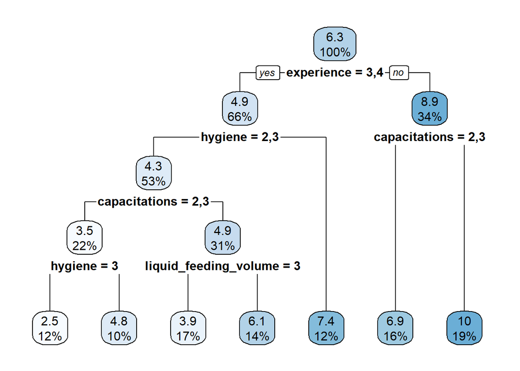

Clasifica los casos. - las particiones que aparecen arriba son las que capturan mayor variabilidad - vas particionando en grupos menores, mas chicos, con menos variablidad - irian en linea con variable importance La media de mortalidad de todas las encuestas es de 6.3%. Si experiencia es mayor o igual a 3, el promedio de mortalidad es 4.9%, y si a su vez capacitacion es mayor igual a 2, tiene un 3.5% en promedio. A su vex si las practicas de higiene son >=3 la mortalidad se reduce al 2,5%.

- Importancia de las variables predictoras sobre mortalidad

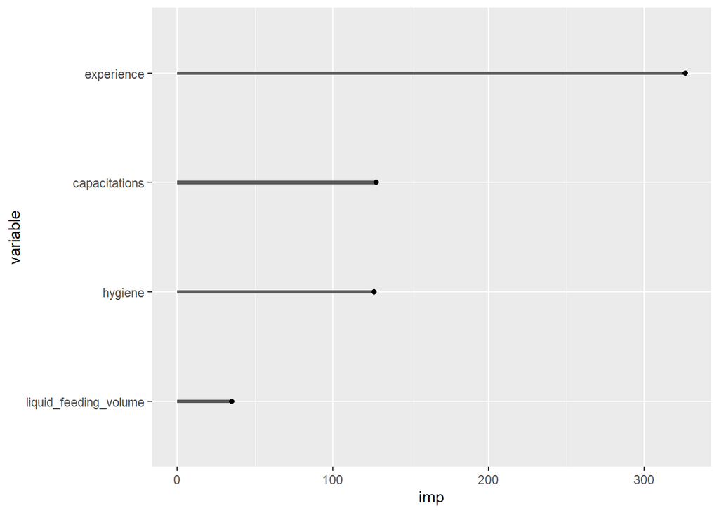

## Random forest

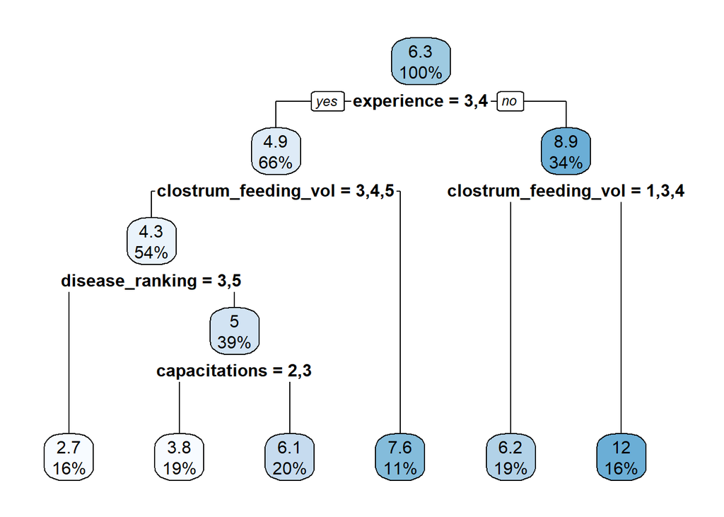

```
## mortality is  2.7 when
##     experience is 3 or 4
##     clostrum_feeding_vol is 3 or 4 or 5
##     disease_ranking is 3 or 5
##
## mortality is  3.8 when
##     experience is 3 or 4
##     clostrum_feeding_vol is 3 or 4 or 5
##     disease_ranking is 1 or 2 or 4
##     capacitations is 2 or 3
##
## mortality is  6.1 when
##     experience is 3 or 4
##     clostrum_feeding_vol is 3 or 4 or 5
##     disease_ranking is 1 or 2 or 4
##     capacitations is 1
##
## mortality is  6.2 when
##     experience is 1 or 2
##     clostrum_feeding_vol is 1 or 3 or 4
##
## mortality is  7.6 when
##     experience is 3 or 4
##     clostrum_feeding_vol is 1 or 2
##
## mortality is 12.1 when
##     experience is 1 or 2
##     clostrum_feeding_vol is 2 or 5
```

```
##  clostrum_feeding_vol            experience    realiza_calostrado
##                  35.0                  29.8                  11.4
##               hygiene       disease_ranking             prepartum
##                   5.5                   4.9                   4.4
##        rearing_system         capacitations calostrum_feeding_num
##                   4.1                   4.0                   0.8
```

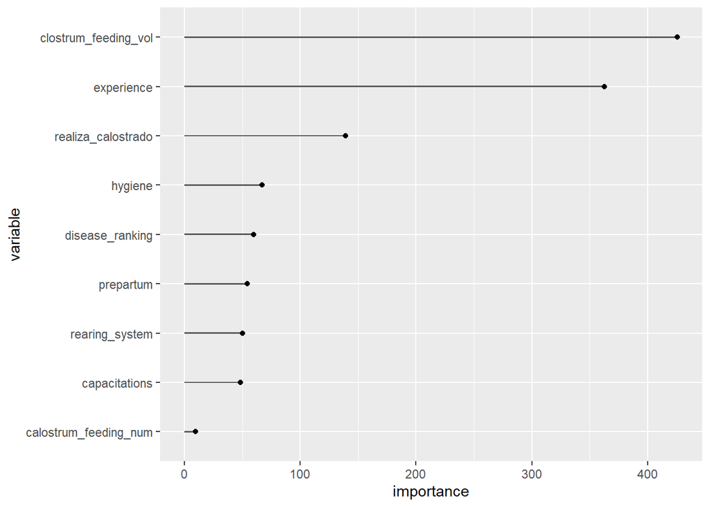